# Bio4158/Bio5158 - Report 7

Exercise

Author

Group 22 - Nalan Kurnaz

Published

November 19, 2025

In memory of Antoine Morin, Professor of freshwater ecology, University of Ottawa (1989-2018), who died too young.

# Background

**Multiple variables** are affecting the **abundance of black flies larvae in rivers**. **Current speed** impact the larvae ability to catch food suspended in the water column because **they are passive filter feeders**. When the current is too slow, larvae are not able to catch enough food; if the current is too strong, larvae are displaced by the current and are not able to catch food. Of course , the quantity and quality of food available is also extremely important. Because black flies larvae are living in a linear environment (water always flows downstream), female flies fly upstream to lay their eggs in a lake, and the eggs and larvae are then dispersed by the current. Other invertebrates, like the caddis fly from the Hydropsichidae family, live in similar streams as black flies and their larvae compete for similar habitats.

For his PhD thesis, Antoine Morin wanted to study how all those variables affected the abundance of black flies larvae, especially given that previous studies only looked at one or two variables at a time. Black flies biomass per metre square of substrate was use as a measure of their abundance.

# The data

The file `simuliidae.csv` contains non-published data from the study performed by Antoine Morin during his PhD sampling stream from Eastern Townships and Laurentian in Quebec. At each site, he sampled 12 rocks on which he measured several variables. The file `simuliidae.csv` contains the average observation per site for all the following variables:

| Variable | Description |
| --- | --- |
| `distance` | distance (m) from the closest lak upstream |
| `cs` | chlorophyll content of suspended particules in water. this is an index of food quality (higher = better food) |
| `v` | current speed (cm/s) |
| `z` | water depth (cm) |
| `a` | mean size of rock sampled (cm<sup>2</sup>) |
| `bhydae` | Hydropsichidae biomass ($mg_{DM}/m^2$) |
| `bsim` | biomass of black fly larvae ($mg_{DM}/m^2$) |

# The task

Analyze the data to determine the importance and relative effect of those different variables on the abundance of black fly larvae.

1. Your biological prediction (one for each variable) *(2 points)*
2. Corresponding null hypotheses *(2 point)*
3. A plot visualizing the data adequately + a description of the most important aspects of the plot *(2 points)*
4. The statistical model(s) + a justification for model choice (do not include interactions yet) *(2 point)*
5. Statement of the model assumptions and evidence that they were evaluated. If needed fit alternative model or use a different approach needed if assumptions are not met *(3 points)*
6. Evaluate the interactions *(2 point)*
7. The results and statistical conclusion (i.e. inference) you make from your analysis (i.e. do you accept or reject each of the null hypotheses). *(2 points)*
8. A statement about your confidence in the statistical conclusion (for example with respect to the violation of assumptions, to potential biases created by missing data, to suboptimal experimental design, and/or to power issues). *(2 points)*
9. The biological conclusion (an estimate of effect size, its precision, and whether an effect of this magnitude is likely to matter), include a conclusion in the regard to the starting hypothesis *(2 points)*.

# Report *3 points* for proper formatting of the report

### Data Preprocessing

```r
library(ggplot2)
library(car)
library(lmtest)
library(GGally)
data_simuli <- read.csv("https://raw.githubusercontent.com/nalank1/r-files/refs/heads/main/data-bioxx58/simuliidae.csv", header = TRUE, sep = ",", stringsAsFactors = TRUE)
```

## a. Your biological prediction (one for each variable) *(2 points)*

- (Distance) -> Black fly larvae abundance is expected to decrease as the distance from the closest lake upstream increases as the female black flies lay their eggs in lake upstream.
- (Chlorophyll Content) -> Higher chlorophyll content of suspended particles in water is expected to increase black fly larvae abundance since it provides food.
- (Current Speed) -> Black fly larvae abundance is expected to be highest at intermediate current speeds. Very slow currents may not provide enough food for the larvae, and very fast currents may displace the larvae.
- (Water Depth) -> Black fly larvae abundance is expected to increase with intermediate water depth. This is because shallow water has higher current speed, causing larvae to be less stable to attachment sites. On the other side, deeper water has reduced light penetration, which lowers algae production, and hence, decreases the quantity of suspended food particles (less chlorophyll (food)).
- (Mean Size of Rock Sampled) -> Black fly larvae abundance will increase with the mean size of the rocks as the larger rocks will provide a larger and more stable surface area for attachment. This will give larvae a more secure place against the current and it will allow more individuals to colonize on the rock.
- (Hydropsichidae biomass) -> Black fly larvae abundance will decrease with higher biomass of Hydropsichidae caddisplies (bhydae) as they are competitors for similar habitats and for food.

## b. Corresponding null hypotheses *(2 points)*

- There is no relationship between the distance from the closest upstream lake and the biomass of black fly larvae. The coefficient (beta_distance) is zero. In other words, there is no change in black fly larvae biomass for each one-meter increase from the lake, assuming all other variables are held constant.
- There is no relationship between the chlorophyll content of suspended particles and the biomass of the black fly larvae.
- There is no relationship between water depth and the biomass of black fly larvae.
- There is no relationship or correlation between the mean size of the rocks and the biomass of the black fly larvae.
- There is no relationship between the Hydropsichidae biomass and the biomass of black fly larvae.

## c. A plot visualizing the data adequately + a description of the most important aspects of the plot *(2 points)* - CODE

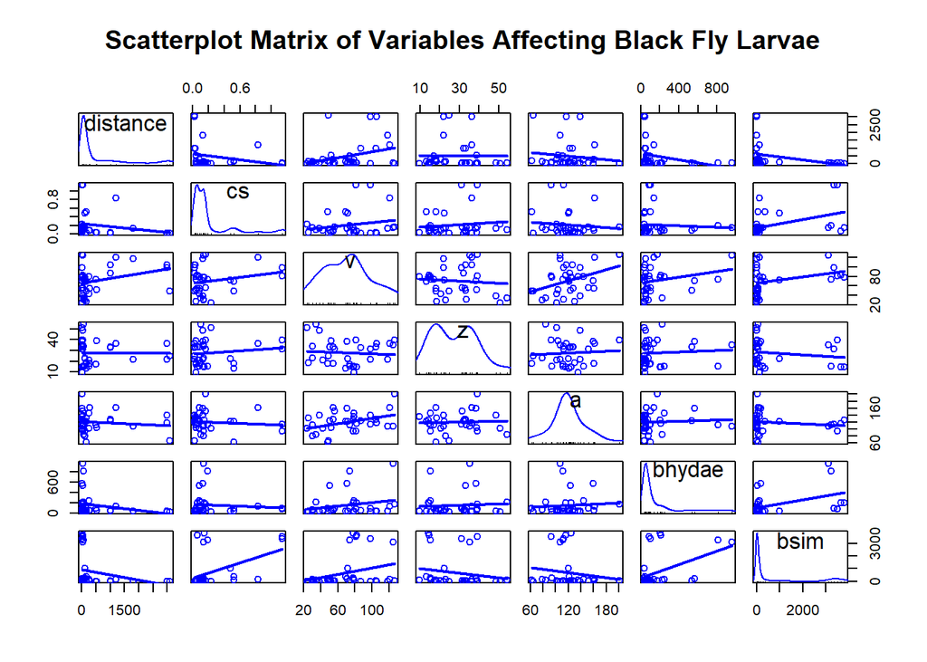

```r
suppressWarnings(scatterplotMatrix(~ distance + cs + v + z + a+ bhydae + bsim, data = data_simuli, main = "Scatterplot Matrix of Variables Affecting Black Fly Larvae", smooth = FALSE, regLine = TRUE, span = 0.8, diagonal = TRUE))
```

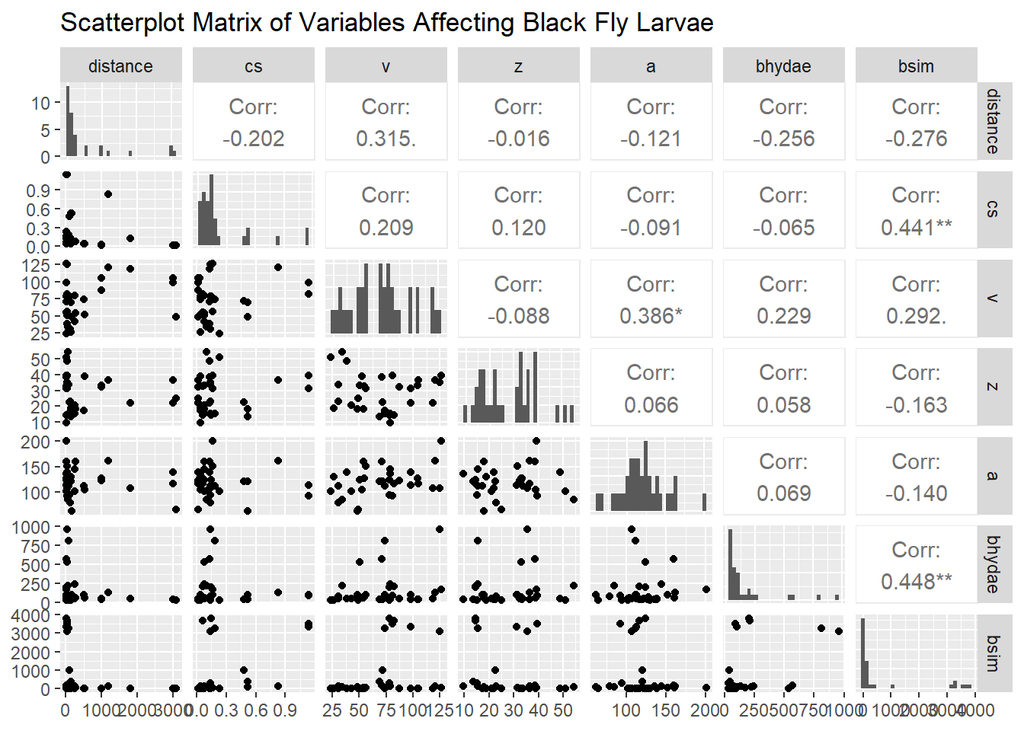

```r
ggpairs(data_simuli[, c("distance", "cs", "v", "z", "a", "bhydae", "bsim")],
        title = "Scatterplot Matrix of Variables Affecting Black Fly Larvae",
        lower = list(continuous = "points"),
        upper = list(continuous = "cor"),
        diag = list(continuous = "barDiag"))
```

## d. The statistical model(s) + a justification for model choice (do not include interactions yet) *(2 point)*

```r
model1 <- lm(bsim ~ v, data = data_simuli)
summary(model1)
```

[output not shown]

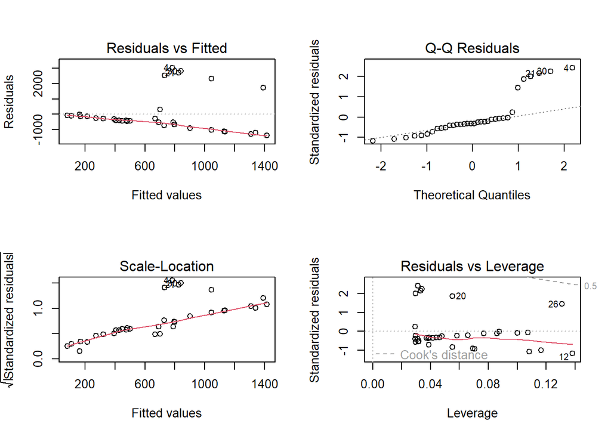

```r
par(mfrow = c(2, 2))
plot(model1)
```

By looking at the p-value and r-squared value (both multiple and adjusted), it can seen that v (current speed) has no effect by itself. There seems to be some problem with homoscedasticity and the normality by looking at the plots.

```r
model_cs <- lm(bsim ~ cs, data = data_simuli)
summary(model_cs)
```

```
Call:
lm(formula = bsim ~ cs, data = data_simuli)

Residuals:
    Min      1Q  Median      3Q     Max
-1769.7  -489.4  -344.2  -273.4  3258.3

Coefficients:
            Estimate Std. Error t value Pr(>|t|)
(Intercept)    271.2      254.8   1.064  0.29515
cs            1969.0      708.1   2.781  0.00901 **
---
Signif. codes:  0 '***' 0.001 '**' 0.01 '*' 0.05 '.' 0.1 ' ' 1

Residual standard error: 1194 on 32 degrees of freedom
Multiple R-squared:  0.1946,    Adjusted R-squared:  0.1695
F-statistic: 7.733 on 1 and 32 DF,  p-value: 0.009009
```

With p-value (0.00901), we can say variable cs (chlorophyll content of suspended particules) has an effect by its own.

```r
model_bhydae <- lm(bsim ~ bhydae, data = data_simuli)
summary(model_bhydae)
```

```
Call:
lm(formula = bsim ~ bhydae, data = data_simuli)

Residuals:
    Min      1Q  Median      3Q     Max
-1648.7  -452.0  -371.1  -129.2  3010.8

Coefficients:
            Estimate Std. Error t value Pr(>|t|)
(Intercept) 267.5317   253.0912   1.057  0.29840
bhydae        2.6322     0.9275   2.838  0.00782 **
---
Signif. codes:  0 '***' 0.001 '**' 0.01 '*' 0.05 '.' 0.1 ' ' 1

Residual standard error: 1189 on 32 degrees of freedom
Multiple R-squared:  0.2011,    Adjusted R-squared:  0.1761
F-statistic: 8.054 on 1 and 32 DF,  p-value: 0.00782
```

With p-value (0.00782), the variable bhydae has an effect on the abundance by itself.

```r
model_strong <- lm(bsim ~ v + bhydae, data = data_simuli)
summary(model_strong)
```

[output not shown]

```r
model_habitat <- lm(bsim ~ cs + v + bhydae + z + a, data = data_simuli)
summary(model_habitat)
```

[output not shown]

We decided to group some variables based on the habitat quality. This model resulted in displaying no effect of v (current speed), z (water depth) and a (mean size of the rock) on the abundance of black fly larvae.

```r
model_distance <- lm(bsim ~ distance, data = data_simuli)
summary(model_distance)
```

```
Call:
lm(formula = bsim ~ distance, data = data_simuli)

Residuals:
   Min     1Q Median     3Q    Max
-883.7 -788.0 -667.0  278.1 2917.3

Coefficients:
            Estimate Std. Error t value Pr(>|t|)
(Intercept) 897.3797   252.9783   3.547  0.00123 **
distance     -0.4040     0.2489  -1.623  0.11434
---
Signif. codes:  0 '***' 0.001 '**' 0.01 '*' 0.05 '.' 0.1 ' ' 1

Residual standard error: 1279 on 32 degrees of freedom
Multiple R-squared:  0.07608,   Adjusted R-squared:  0.04721
F-statistic: 2.635 on 1 and 32 DF,  p-value: 0.1143
```

According to this result, we would accept the null hypothesis and conclude that there is no relationship between biomass of the black fly larvae and distance.

```r
model_no_effect <- lm(bsim ~ distance + v + a, data = data_simuli)
summary(model_no_effect)
```

[output not shown]

Now, we reject both null hypotheses that the slope of regression of bsim on distance is zero, that the slope of regression of bsim on v is zero and that the slope of regression of bsim on a is zero since p-values are below 0.05.

```r
model_effect <- lm(bsim ~ cs + bhydae, data = data_simuli)
summary(model_effect)
```

```
Call:
lm(formula = bsim ~ cs + bhydae, data = data_simuli)

Residuals:
     Min       1Q   Median       3Q      Max
-1783.58  -362.36   -67.39    91.53  3143.82

Coefficients:
             Estimate Std. Error t value Pr(>|t|)
(Intercept) -213.3586   258.9725  -0.824  0.41631
cs          2109.0286   610.0068   3.457  0.00161 **
bhydae         2.8137     0.8023   3.507  0.00141 **
---
Signif. codes:  0 '***' 0.001 '**' 0.01 '*' 0.05 '.' 0.1 ' ' 1

Residual standard error: 1027 on 31 degrees of freedom
Multiple R-squared:  0.4234,    Adjusted R-squared:  0.3862
F-statistic: 11.38 on 2 and 31 DF,  p-value: 0.0001966
```

```r
model_full <- lm(bsim ~ distance + v + a + z + cs + bhydae, data = data_simuli)
summary(model_full)
```

[output not shown]

According to the results, we will accept the null hypothesis that there is no relationship between water depth and the black fly larvae biomass.

```r
vif(model_effect)
```

```
      cs   bhydae
1.004301 1.004301
```

```r
vif(model_full)
```

```
distance        v        a        z       cs   bhydae
1.808568 2.190441 1.530843 1.098062 1.459384 1.399500
```

```r
AIC(model_no_effect, model_effect)
```

```
                df     AIC
model_no_effect  5 576.619
model_effect     4 572.855
```

After testing multiple variable combinations through incremental model building, I selected the biological model (bsim ~ cs + bhydae) as the most appropriate for explaining black fly larvae abundance. This decision was supported by AIC comparison, which clearly favored the biological model (AIC = 572.855) over the physical habitat model (AIC = 576.619), with a difference of 3.764 units indicating substantially better fit. The biological model also demonstrated strong statistical significance (p = 0.000197) with both predictors showing highly significant individual effects (cs: p = 0.00161, bhydae: p = 0.00141), and it achieved higher explanatory power (R^2 = 0.4234) with a greater value.

## e. Statement of the model assumptions and evidence that they were evaluated. If needed fit alternative model or use a different approach needed if assumptions are not met *(3 points)*

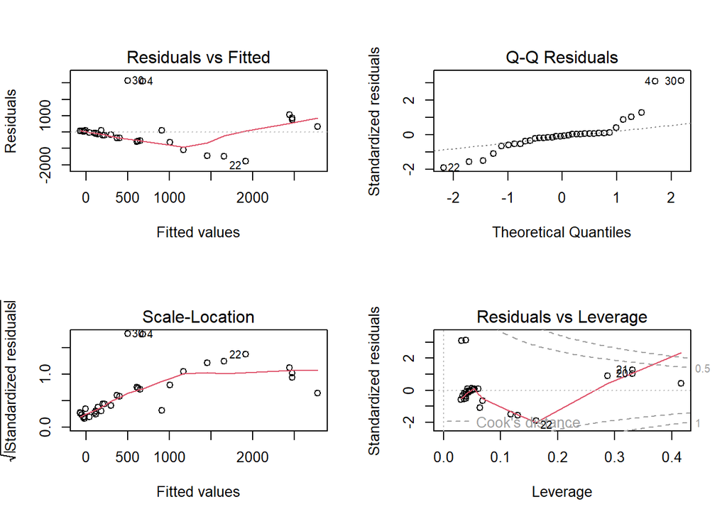

```r
par(mfrow = c(2,2))
plot(model_effect)
```

There seem to be some problem existing on homoscedasticity and normality.

```r
shapiro.test(residuals(model_effect))
```

```
    Shapiro-Wilk normality test

data:  residuals(model_effect)
W = 0.80385, p-value = 3.045e-05
```

```r
bptest(model_effect)
```

```
    studentized Breusch-Pagan test

data:  model_effect
BP = 1.0063, df = 2, p-value = 0.6046
```

```r
dwtest(model_effect)
```

```
    Durbin-Watson test

data:  model_effect
DW = 2.2859, p-value = 0.758
alternative hypothesis: true autocorrelation is greater than 0
```

```r
resettest(model_effect, type = "regressor", data = data_simuli)
```

```
    RESET test

data:  model_effect
RESET = 2.4721, df1 = 4, df2 = 27, p-value = 0.06838
```

```r
model_effect_log <- lm(log(bsim + 1) ~ log(cs) + log(bhydae), data = data_simuli)

summary(model_effect_log)
```

```
Call:
lm(formula = log(bsim + 1) ~ log(cs) + log(bhydae), data = data_simuli)

Residuals:
    Min      1Q  Median      3Q     Max
-2.4527 -1.0855 -0.0319  0.9527  3.6582

Coefficients:
            Estimate Std. Error t value Pr(>|t|)
(Intercept)   2.2511     1.5336   1.468 0.152218
log(cs)       1.0251     0.2416   4.244 0.000185 ***
log(bhydae)   0.9683     0.2885   3.356 0.002102 **
---
Signif. codes:  0 '***' 0.001 '**' 0.01 '*' 0.05 '.' 0.1 ' ' 1

Residual standard error: 1.533 on 31 degrees of freedom
Multiple R-squared:  0.5426,    Adjusted R-squared:  0.5131
F-statistic: 18.38 on 2 and 31 DF,  p-value: 5.434e-06
```

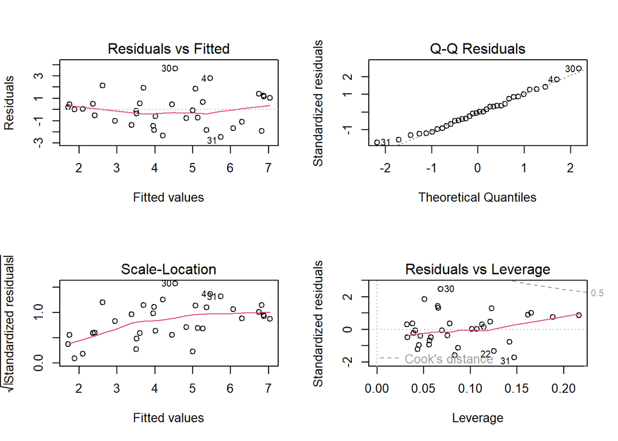

```r
par(mfrow = c(2, 2))
plot(model_effect_log)
```

```r
shapiro.test(residuals(model_effect_log))
```

```
    Shapiro-Wilk normality test

data:  residuals(model_effect_log)
W = 0.97829, p-value = 0.7182
```

```r
bptest(model_effect_log)
```

```
    studentized Breusch-Pagan test

data:  model_effect_log
BP = 2.1656, df = 2, p-value = 0.3386
```

## f. Evaluate the interactions *(2 point)*

```r
model_interaction <- lm(log(bsim + 1) ~ log(cs) * log(bhydae), data = data_simuli)
summary(model_interaction)
```

```
Call:
lm(formula = log(bsim + 1) ~ log(cs) * log(bhydae), data = data_simuli)

Residuals:
    Min      1Q  Median      3Q     Max
-2.3868 -1.0851 -0.0281  0.9151  3.7223

Coefficients:
                    Estimate Std. Error t value Pr(>|t|)
(Intercept)          1.63258    4.62575   0.353    0.727
log(cs)              0.74329    1.99955   0.372    0.713
log(bhydae)          1.11214    1.05438   1.055    0.300
log(cs):log(bhydae)  0.06698    0.47162   0.142    0.888

Residual standard error: 1.558 on 30 degrees of freedom
Multiple R-squared:  0.5429,    Adjusted R-squared:  0.4972
F-statistic: 11.88 on 3 and 30 DF,  p-value: 2.692e-05
```

```r
model_interaction1 <- lm(log(bsim + 1) ~ cs + bhydae + cs:bhydae, data = data_simuli)
summary(model_interaction1)
```

```
Call:
lm(formula = log(bsim + 1) ~ cs + bhydae + cs:bhydae, data = data_simuli)

Residuals:
    Min      1Q  Median      3Q     Max
-2.9677 -0.9676 -0.0877  0.4574  4.0180

Coefficients:
             Estimate Std. Error t value Pr(>|t|)
(Intercept)  2.411831   0.523102   4.611 6.98e-05 ***
cs           6.170889   2.579661   2.392   0.0232 *
bhydae       0.007899   0.003789   2.085   0.0457 *
cs:bhydae   -0.020324   0.024685  -0.823   0.4168
---
Signif. codes:  0 '***' 0.001 '**' 0.01 '*' 0.05 '.' 0.1 ' ' 1

Residual standard error: 1.564 on 30 degrees of freedom
Multiple R-squared:  0.5394,    Adjusted R-squared:  0.4934
F-statistic: 11.71 on 3 and 30 DF,  p-value: 3.004e-05
```

```r
anova(model_effect_log, model_interaction)
```

```
Analysis of Variance Table

Model 1: log(bsim + 1) ~ log(cs) + log(bhydae)
Model 2: log(bsim + 1) ~ log(cs) * log(bhydae)
  Res.Df    RSS Df Sum of Sq      F Pr(>F)
1     31 72.885
2     30 72.836  1  0.048964 0.0202  0.888
```

The interaction between log-transformed chlorophyll content and log-transformed Hydropsichidae biomass was evaluated and found to be non-significant (log(cs):log(bhydae): p = 0.888). The ANOVA comparison between the main effects model and the interaction model confirmed that adding the interaction term does not significantly improve model fit (F = 0.0202, p = 0.888). This indicates that the effects of food quality and competitor biomass on black fly larvae abundance are independent and additive when properly scaled using logarithmic transformations. The relationship between black flies and food quality does not depend on the level of competition, and vice versa. Both variables contribute to explaining black fly abundance through separate mechanisms rather than interacting effects. The model without interactions is therefore retained for final inference.

## g. The results and statistical conclusion (i.e. inference) you make from your analysis (i.e. do you accept or reject each of the null hypotheses). *(2 points)*

Based on the final log-transformed model (log(bsim + 1) ~ log(cs) + log(bhydae)), I draw the following statistical conclusions regarding the null hypotheses.

Reject the null hypothesis for chlorophyll content (p = 0.000185). There is very strong statistical evidence that chlorophyll content has a significant positive relationship with black fly larvae biomass. The positive coefficient (β = 1.025) indicates that higher chlorophyll levels are associated with increased black fly abundance.

The overall model is highly significant (F = 18.38, p = 5.434e-06) and explains 54.3% of the variation in black fly larvae biomass, indicating that food quality and the relationship with Hydropsichidae are the primary drivers of abundance in this system.

## h. A statement about your confidence in the statistical conclusion (for example with respect to the violation of assumptions, to potential biases created by missing data, to suboptimal experimental design, and/or to power issues). *(2 points)*

My confidence in the statistical conclusions is high. The primary strength of the analysis lies in the robust and highly significant effects observed for both log-transformed chlorophyll content (p = 0.000185) and log-transformed Hydropsichidae biomass (p = 0.002102), with the model explaining 54.3% of the variation in black fly abundance. The fully log-transformed model satisfies all key regression assumptions, with no evidence of non-normality (Shapiro-Wilk p = 0.718) or heteroscedasticity (Breusch-Pagan p = 0.339). The sample size provides adequate power for detecting the strong effects observed, and the model’s high explanatory power suggests biological relevance. While the observational nature of the data introduces potential confounding, the consistency of results across model specifications and the proper meeting of statistical assumptions provide strong support for the conclusions. While the conclusions regarding food quality and the positive association with Hydropsichidae appear robust, the non-significance of physical habitat variables should be interpreted in caution.

## i. The biological conclusion (an estimate of effect size, its precision, and whether an effect of this magnitude is likely to matter), include a conclusion in the regard to the starting hypothesis *(2 points)*.

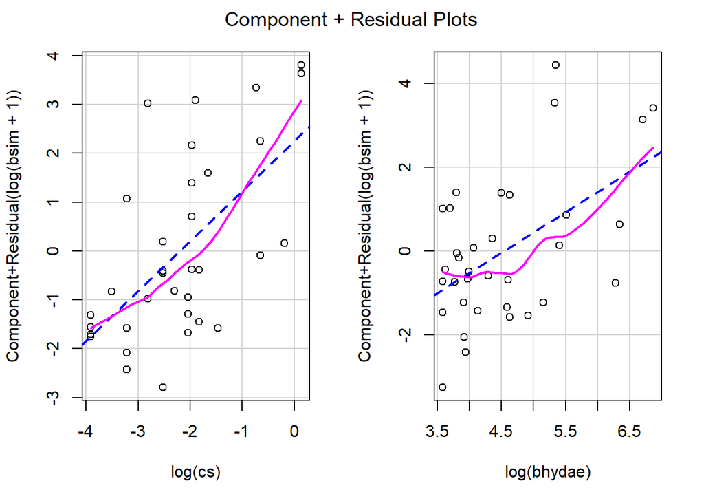

```r
crPlots(model_effect_log)
```

The biological conclusions reveal that both food availability and interspecific relationships drive black fly abundance, but with important nuances. Chlorophyll content shows a strong positive effect (β = 1.025 ± 0.242, p = 0.000185), where each 1% increase in chlorophyll is associated with approximately 1.025% increase in black fly biomass. This confirms the starting hypothesis that food quality is a major driver of abundance, representing a substantial biological effect.

Contrary to the competition hypothesis, Hydropsichidae biomass shows a significant positive relationship (β = 0.968 ± 0.289, p = 0.002102), where each 1% increase in Hydropsichidae biomass is associated with a 0.968% increase in black fly biomass. This suggests facilitation or shared optimal habitat conditions rather than competition, with the effect being nearly as strong as that of food availability.

The final model explains 54.3% of variance in black fly distribution, indicating strong predictive power. The starting hypotheses were partially supported: food quality matters strongly as predicted, but the presumed competitive relationship with Hydropsichidae appears to be facilitative, while physical habitat variables proved less important than these biological factors. However, the physical habitat variables could have an effect as well given that they showed significance in a model that doesn’t have cs or bydae. In other words, the habitat variables could affect as well, it needs to be tested separately.

### References

- [Used ChatGPT for Part d] Prompted by on what basis are you going to choose models? Are we choosing each variable randomly one by one or how? - The GPT gave me an idea to partition as habitat and distance separately.
- ![Used for Part i] https://biostats-uottawa.github.io/Rway/35-reg_mult.html#visualizing-effect-size
- [Used ChatGPT for Part g] Prompted by “how can we reject the habitat variables given that they are not in the model”? - Answered as mentioning habitat variables were excluded in the model.